# Communicating Data Findings (Ford GoBike System Data)

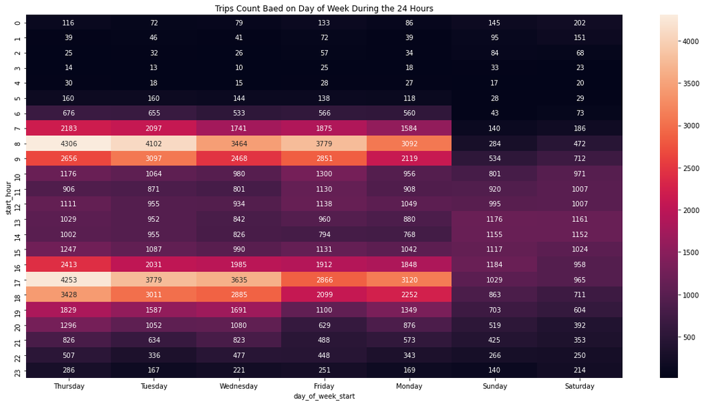

```python
def heat_map(col1,col2,title):
    ''' This function is to create a heatmap only after groupping columns'''
    counts = df.groupby([col1, col2]).size()
    counts = counts.reset_index(name='count')
    counts = counts.pivot(index = col1, columns = col2 , values = 'count')

    plt.figure(figsize=(20,10))
    sb.heatmap(counts, annot = True, fmt = 'd')
    plt.title(title);


#plot heatmap for two columns: start_hour, day_of_week_start
heat_map('start_hour', 'day_of_week_start', 'Trips Count Baed on Day of Week During the 24 Hours')
```

> As we noticed before, the popular time for trips was in weekdays not in weekends and the most popular time period was from the 8 am to 9 am in the morning and from 4 pm to 6 pm in the evening in weekdays.

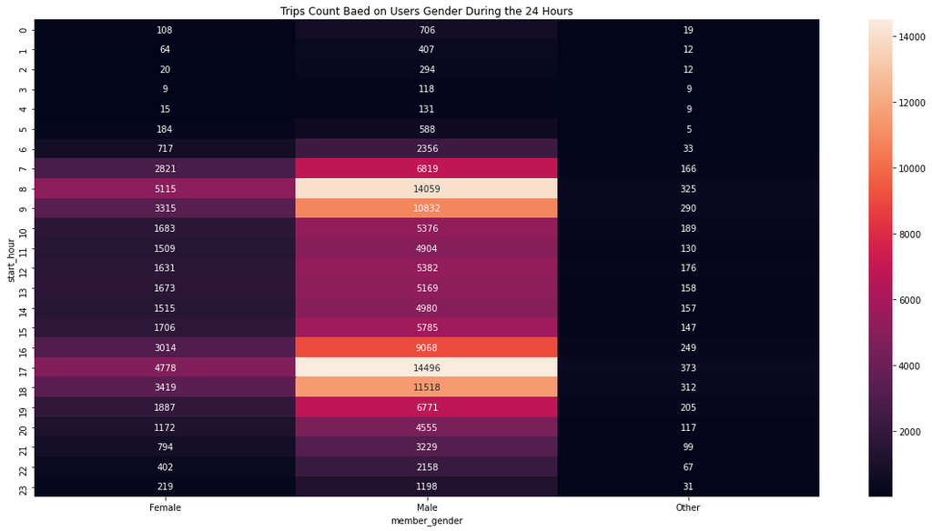

```python
#plot heatmap for two columns: start_hour, member_gender
heat_map('start_hour', 'member_gender', 'Trips Count Baed on Users Gender During the 24 Hours')
```

> The number of trips for male is more than female. The time period for male is between 6 am - 22 pm and the most popular time is 5 pm and 8 am, while for female is between 7 am - 9 am and between 4 pm - 6 pm and the most popular time is also 5 pm and 8 am

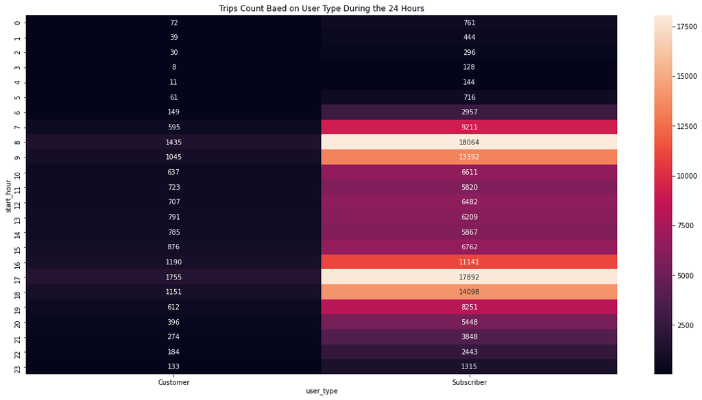

```python
#plot heatmap for two columns: start_hour, user_type
heat_map('start_hour', 'user_type', 'Trips Count Baed on User Type During the 24 Hours')
```

> The number of trips for subsriber users is more than customer. The time period is between 6 am - 22 pm and most popular time period 5 pm and 8 am.

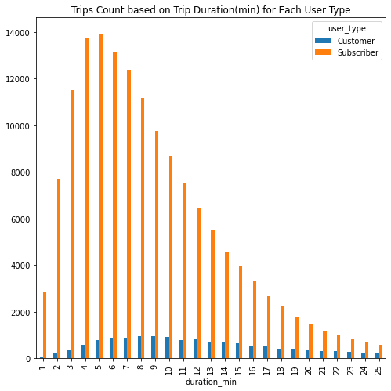

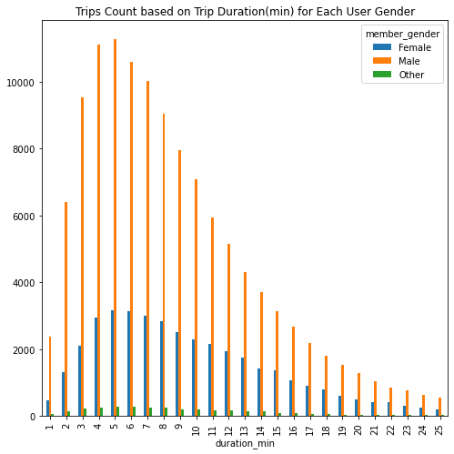

```python
def clustered_bar(col1,col2,title):
    '''This function is to create clustered bar chart'''
    counts = df.groupby([col1, col2]).size()
    counts = counts.reset_index(name='count')
    counts = counts.pivot(index = col1, columns = col2, values = 'count')

    counts.plot(kind='bar', figsize = (8,8))
    plt.title(title);


clustered_bar('duration_min', 'user_type', 'Trips Count based on Trip Duration(min) for Each User Type')
clustered_bar('duration_min', 'member_gender', 'Trips Count based on Trip Duration(min) for Each User Gender')
```

> The highest duration in minutes for subscriber is 5 min with about 14,000 trips and for customer is 9 min with about 1,000 trips. The highest duration in minutes for male is 5 min with more than 10,000 trips and for female is also 5 min with about 3,000 trips.

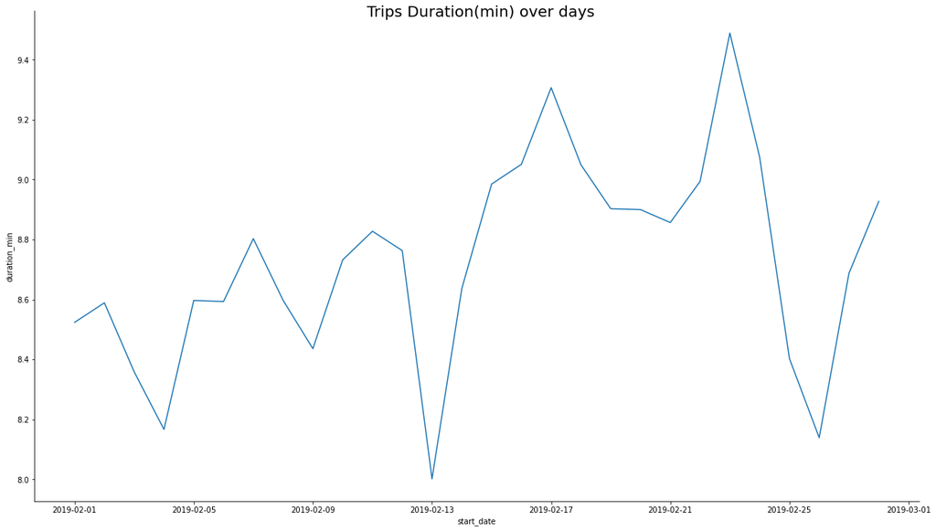

```python
#plot line chart to track the trip duration in minutes for start date
line_chart = sb.relplot(x = 'start_date', y = 'duration_min', data = df, kind= 'line', ci= None, estimator= 'mean' )
line_chart.fig.set_size_inches(20,10)
line_chart.fig.suptitle('Trips Duration(min) over days', fontsize=20);
```

### Talk about some of the relationships you observed in this part of the investigation. How did the feature(s) of interest vary with other features in the dataset?

`Based on trips day of week:`

**- Age**: The median was about 34 years in weekdays and about 32 years in weekend.

**- User Type**: In each day, number of trips for subscriber users is more than customer users and the highest number of trips for subscriber users was on Thursday with about 29,000 trips also for customers was on Thursday but the with about 3,000 trips.

**- Gender Type**: In each day, number of trips for male users was more than other gender users and the highest number of trips for male users was on Thursday with about 23,000 trips and for female aslo was on Thursday but with about 8,000 trips.

`Based on trips hour start:`

**- Day of Week**: The popular time for trips was in weekdays not in weekends and the most popular time period was from the 8 am to 9 am in the morning and from 4 pm to 6 pm in the evening in weekdays.

**- User Type**: The number of trips for subsriber users is more than customer. The time period is between 6 am - 22 pm and most popular time period 5 pm and 8 am.

**- Gender Type**: The number of trips for male is more than female. The time period for male is between 6 am - 22 pm and the most popular time is 5 pm and 8 am, while for female is between 7 am - 9 am and between 4 pm - 6 pm and the most popular time is also 5 pm and 8 am

`Based on trips duration in minutes:`

**- User Type**: TThe highest duration in minutes for subscriber is 5 min with about 14,000 trips and for customer is 9 min with about 1,000 trips

**- Gender Type**: The highest duration in minutes for male is 5 min with more than 10,000 trips and for female is also 5 min with about 3,000 trips.

### Did you observe any interesting relationships between the other features (not the main feature(s) of interest)?

Between user type and member gender the number of trips for male was more than other for both user type subscriber and customer.

## Multivariate Exploration

```python
def heatmap_bar(cat_col1, cat_col2,num_col, title, title2):
    '''This function is to create heatmap and bar chart together for 3 different columns'''
    plt.figure(figsize = [20, 10])
    median = df.groupby([cat_col1, cat_col2]).median()[num_col]
    median = median.reset_index(name = num_col)
    median = median.pivot(index = cat_col1, columns = cat_col2,
                            values = num_col)
    sb.heatmap(median, annot = True, fmt = '.3f',
           cbar_kws = {'label' : title})
    plt.title(title2);

    plt.figure(figsize = [8, 8])
    ax = sb.barplot(data = df, x = cat_col2 , y = num_col  , hue = cat_col1)
    ax.legend(loc = 8, ncol = 3, framealpha = 1, title = cat_col2)
    plt.title(title2);
```

## 1- The Median of Trips Duration in Minutes for Each User Type in Each day

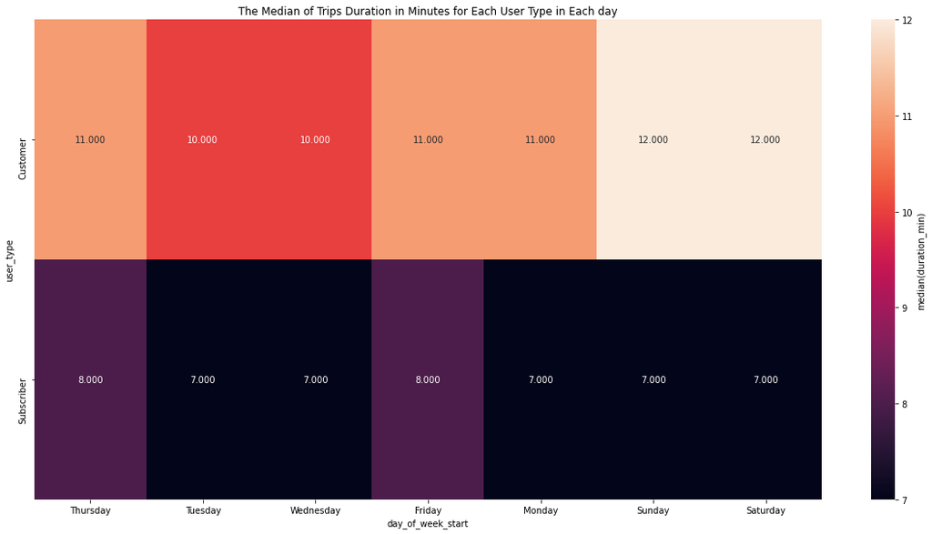

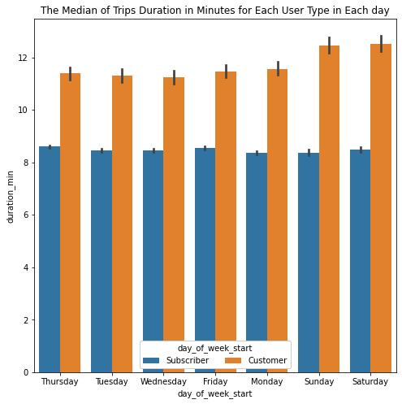

```python
heatmap_bar('user_type', 'day_of_week_start','duration_min', 'median(duration_min)',
            'The Median of Trips Duration in Minutes for Each User Type in Each day' )
```

> The customer users has median duration higher than subscriber .The highest median for customer was in the weekend while the subscriber has the lowest median in weekend.

## 2- The Median of Trips Duration in Minutes for Each User Type for Each Gender

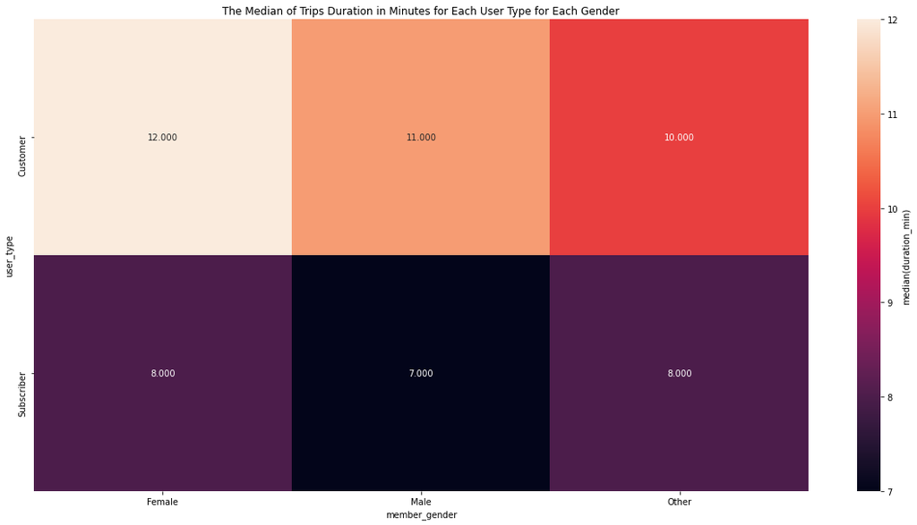

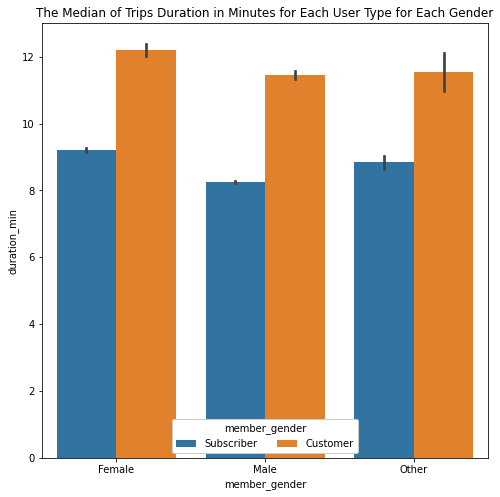

```python
heatmap_bar('user_type', 'member_gender','duration_min', 'median(duration_min)',
           'The Median of Trips Duration in Minutes for Each User Type for Each Gender')
```

> The customer users has median duration higher than subscriber for each gender and the female customer users has the highest median than other gender (12 min).

## 3- The Median of Bike Users for Each User Type in Each day

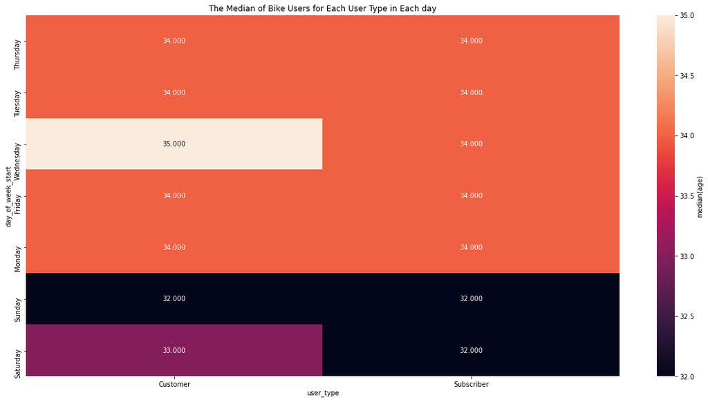

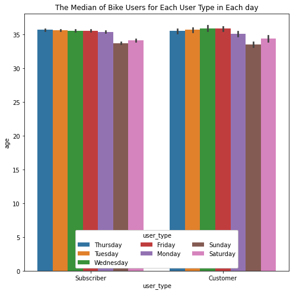

```python
heatmap_bar('day_of_week_start', 'user_type','age', 'median(age)',
           'The Median of Bike Users for Each User Type in Each day')
```

> The median age for customer and subscriber users is almost similar in weekdays and weekend and the highest median age was for customer user on Wednesday (35 years).

### Talk about some of the relationships you observed in this part of the investigation. Were there features that strengthened each other in terms of looking at your feature(s) of interest?

I extended my investigation of trips duration (min) and age in this section by looking at three categorical features 'user_type', 'member_gender', and 'day_of_week_start'. The multivariate exploration here showed that the median of trip duration for customer was the highest in all the day of week for all gender types than subscriber. The female customer users has the highest median than other gender. The highest median for customer was in the weekend while the subscriber has the lowest median in weekend. The median age for customer and subscriber users is almost similar in weekdays and weekend and the highest median age was for customer user on Wednesday (35 years).

### Were there any interesting or surprising interactions between features?

In previous section, the trip duration for subscriber users and male gender was higher but in this section with multivariate, the customer duration is the highest especially in weekend and the female is highest than other gender.

# Resources:

https://www.youtube.com/watch?v=3aOtG9ns_Ko

https://www.youtube.com/watch?v=UFuo7EHI8zc

https://www.datasciencemadesimple.com/difference-two-timestamps-seconds-minutes-hours-pandas-python-2/

https://stackoverflow.com/questions/33379439/python-pandas-date-time-conversion-to-date